# ali_emre_kurekci_final

Ali Emre Kürekci

15 01 2021

```r
library(caret)
data <- read.csv('./online_shoppers_intention.csv')
delete_col_nums <- c(11)
if(!is.null(delete_col_nums)){
    data <- data[, -delete_col_nums]
}
# Structure of the dataframe
str(data)
```

```
## 'data.frame':    12330 obs. of  17 variables:
##  $ Administrative         : int  0 0 0 0 0 0 0 1 0 0 ...
##  $ Administrative_Duration: num  0 0 0 0 0 0 0 0 0 0 ...
##  $ Informational          : int  0 0 0 0 0 0 0 0 0 0 ...
##  $ Informational_Duration : num  0 0 0 0 0 0 0 0 0 0 ...
##  $ ProductRelated         : int  1 2 1 2 10 19 1 0 2 3 ...
##  $ ProductRelated_Duration: num  0 64 0 2.67 627.5 ...
##  $ BounceRates            : num  0.2 0 0.2 0.05 0.02 ...
##  $ ExitRates              : num  0.2 0.1 0.2 0.14 0.05 ...
##  $ PageValues             : num  0 0 0 0 0 0 0 0 0 0 ...
##  $ SpecialDay             : num  0 0 0 0 0 0 0.4 0 0.8 0.4 ...
##  $ OperatingSystems       : int  1 2 4 3 3 2 2 1 2 2 ...
##  $ Browser                : int  1 2 1 2 3 2 4 2 2 4 ...
##  $ Region                 : int  1 1 9 2 1 1 3 1 2 1 ...
##  $ TrafficType            : int  1 2 3 4 4 3 3 5 3 2 ...
##  $ VisitorType            : chr  "Returning_Visitor" "Returning_Visitor" "Returning_Visitor" "Returning_Visitor" ...
##  $ Weekend                : logi  FALSE FALSE FALSE FALSE TRUE FALSE ...
##  $ Revenue                : logi  FALSE FALSE FALSE FALSE FALSE FALSE ...
```

```r
label_name <- "Revenue"
temp_label <- paste(label_name, " ~ ." )
col_num <- ncol(data)
label_name_col <- c("Revenue")
```

# Missing data handling

```r
missing_method <- NULL
if(!is.null(missing_method)){
  library(mice)
  library(VIM)
  sapply(data, function(x) sum(is.na(x)))
  summary(data)

  mice_plot <- aggr(data, col=c('navyblue','red'),
                    numbers=TRUE,labels=names(data),
                    ylab=c("Missing data", "Pattern"))
  imp<-mice(data, meth=missing_method)
  data <- complete(imp)
}
```

# Noise filtering

I provided noise filtiring option tu the users if they would like to use this option it is enough to give noise action type as input to the main function. Then they can display the noise rows. I should say that, I used noise filters package first time in my life and I could not get any result in short time for our dataset. For the iris data that has small row size, it is working pretty good but I do not prefer to use this option in our case.

```r
noise <- FALSE
noise_filter <- function(d, n_type){
    library(ggplot2)
    library(NoiseFiltersR)
    label_col_num <- which(colnames(data) == label_name)
    for(i in 1:ncol(d)){
      if(typeof(d[,i]) == "character" || typeof(d[,i]) == "logical"){
        d[,i] = as.factor(d[,i])
      }
    }
    #hybrid or remove
    out <- hybridRepairFilter(d, noiseAction = n_type, classColumn = label_col_num)
    summary(out, explicit = TRUE)
}
if(noise){
  noise_filter(data, "remove")
}
```

# Class Balancing

```r
library(imbalance)
library(DMwR)
smoted = TRUE
smote_data <- function(d){
  smotedata <- d[, c(1:ncol(d))]
  for(i in 1:ncol(smotedata)){
    if(typeof(smotedata[,i]) == "character" || typeof(smotedata[,i]) == "logical"){
      smotedata[,i] = as.factor(smotedata[,i])
    }
  }
  smoted_data <<- SMOTE(as.formula(temp_label),data = smotedata, perc.over = 200,
                   perc.under=150)

  return(smoted_data)
}
if(smoted){
  data <- smote_data(data)
}
str(data)
```

```
## 'data.frame':    11448 obs. of  17 variables:
##  $ Administrative         : num  3 0 0 3 6 0 0 0 1 3 ...
##  $ Administrative_Duration: num  34.8 0 0 82.5 122.8 ...
##  $ Informational          : num  0 2 0 1 0 0 0 0 0 0 ...
##  $ Informational_Duration : num  0 33 0 56.5 0 0 0 0 0 0 ...
##  $ ProductRelated         : num  30 21 5 54 7 25 4 10 12 9 ...
##  $ ProductRelated_Duration: num  709.8 1277.8 43.2 2295 175.4 ...
##  $ BounceRates            : num  0.02667 0.0087 0.08 0.00727 0 ...
##  $ ExitRates              : num  0.0467 0.037 0.12 0.0145 0.0182 ...
##  $ PageValues             : num  0 0 0 0 0 ...
##  $ SpecialDay             : num  0 0 0 0 0 0.4 0 0 0 0 ...
##  $ OperatingSystems       : num  1 2 2 1 2 2 2 2 2 2 ...
##  $ Browser                : num  1 2 2 1 5 2 4 2 2 2 ...
##  $ Region                 : num  2 7 3 1 5 1 9 1 9 7 ...
##  $ TrafficType            : num  1 6 13 10 2 4 4 1 1 6 ...
##  $ VisitorType            : Factor w/ 3 levels "New_Visitor",..: 3 3 3 3 1 3 3 3 3 3 ...
##  $ Weekend                : Factor w/ 2 levels "FALSE","TRUE": 2 2 2 2 1 1 1 1 1 1 ...
##  $ Revenue                : Factor w/ 2 levels "FALSE","TRUE": 1 1 1 1 1 1 1 1 1 1 ...
```

# Data Partition

Data is seperated 80% for train and 20% for test by default. I gave this as configurable for user by parameter. in main pipeline function on R file. Also I extracted x and y values from train data part for future usage.

```r
set.seed(100)
label_col_num <- which(colnames(data) == label_name)

# Step 1: Get row numbers for the training data
trainRowNumbers <- createDataPartition(data[,label_col_num], p=0.8,
                                       list=FALSE)

# Step 2: Create the training  dataset
trainData <- data[trainRowNumbers,]

# Step 3: Create the test dataset
testData <- data[-trainRowNumbers,]

# Store X and Y for later use.
x = trainData[, -label_col_num]

y = trainData[,label_col_num]
```

# Descriptive statistic

The skimr package presents us finding any missing values in training data set. It informs us about all columns such as missing value count, standard deviation and column complate rate.

```r
library(skimr)
library(rlang)
skimmed <- skimr::skim(trainData)
skimmed[, c(1:5, 9:11, 13, 15)]
```

Data summary

| Name | trainData |
| --- | --- |
| Number of rows | 9160 |
| Number of columns | 17 |
| _______________________ |  |
| Column type frequency: |  |
| factor | 3 |
| numeric | 14 |
| ________________________ |  |
| Group variables | None |

**Variable type: factor**

| skim_variable | n_missing | complete_rate | ordered |
| --- | --- | --- | --- |
| VisitorType | 0 | 1 | FALSE |
| Weekend | 0 | 1 | FALSE |
| Revenue | 0 | 1 | FALSE |

**Variable type: numeric**

| skim_variable | n_missing | complete_rate | sd | p0 | p25 | p75 | hist |
| --- | --- | --- | --- | --- | --- | --- | --- |
| Administrative | 0 | 1 | 3.31 | 0 | 0.00 | 4.00 | ▇▁▁▁▁ |
| Administrative_Duration | 0 | 1 | 173.21 | 0 | 0.00 | 109.83 | ▇▁▁▁▁ |
| Informational | 0 | 1 | 1.23 | 0 | 0.00 | 0.40 | ▇▁▁▁▁ |
| Informational_Duration | 0 | 1 | 131.95 | 0 | 0.00 | 1.34 | ▇▁▁▁▁ |
| ProductRelated | 0 | 1 | 45.82 | 0 | 11.00 | 41.00 | ▇▁▁▁▁ |
| ProductRelated_Duration | 0 | 1 | 1924.96 | 0 | 333.23 | 1607.45 | ▇▁▁▁▁ |
| BounceRates | 0 | 1 | 0.04 | 0 | 0.00 | 0.01 | ▇▁▁▁▁ |
| ExitRates | 0 | 1 | 0.04 | 0 | 0.01 | 0.03 | ▇▁▁▁▁ |
| PageValues | 0 | 1 | 26.24 | 0 | 0.00 | 21.43 | ▇▁▁▁▁ |
| SpecialDay | 0 | 1 | 0.17 | 0 | 0.00 | 0.00 | ▇▁▁▁▁ |
| OperatingSystems | 0 | 1 | 0.85 | 1 | 2.00 | 2.00 | ▇▂▁▁▁ |
| Browser | 0 | 1 | 1.70 | 1 | 2.00 | 2.00 | ▇▁▁▁▁ |
| Region | 0 | 1 | 2.38 | 1 | 1.00 | 4.00 | ▇▅▁▂▁ |
| TrafficType | 0 | 1 | 3.78 | 1 | 2.00 | 4.00 | ▇▁▁▁▁ |

# Creating imputation model on the training data

Our online shoppers intention data is very clear data so actually we do not need any imputation but at the end of the day I am creating a general ml pipeline function. Besides missing imputation with the help of preProcess function we can apply many preprocess steps on the train data such as scaling and centering. Therefore I added preProcess function with knnImputation method which is well know modern imputation missing value method. However I provided bagImpute method for the pipeline users. I applied the preprocessing by ignoring categorical columns.

```r
head(trainData[,c(11:14)])
```

```
##      OperatingSystems Browser Region TrafficType
## 470                 1       1      2           1
## 5185                2       2      7           6
## 8057                1       1      1          10
## 7788                2       5      5           2
## 5248                2       2      1           4
## 7164                2       4      9           4
```

```r
numerics_as_categorical <- c(11:14)

preProcess_missingdata_model <- preProcess(trainData[, -numerics_as_categorical], method="knnImpute")
preProcess_missingdata_model
```

```
## Created from 9160 samples and 13 variables
##
## Pre-processing:
##   - centered (10)
##   - ignored (3)
##   - 5 nearest neighbor imputation (10)
##   - scaled (10)
```

# Ensuring there is not any NA value

```r
library(RANN)
anyNA(trainData)
```

```
## [1] FALSE
```

```r
trainData <- predict(preProcess_missingdata_model, newdata = trainData)
anyNA(trainData)
```

```
## [1] FALSE
```

# One-hot Encoding

Creating dummy variables for categorical columns. This process generates new columns for individual categories without touching the label column and numeric columns. As you see in the result, VisitorType column seperated as VisitorType.New_Visitor, VisitorType.Other, VisitorType.Returning_Visitor which are elements of VisitorType columns and Wekend column extracted as Weekend.FALSE and Weekend.TRUE.

```r
label_name <- "Revenue"
temp_label <- paste(label_name, " ~ ." )
dummies_model <- dummyVars(temp_label, data=trainData)

# Create the dummy variables using predict. The Y variable (Revenue) will not be present in trainData_mat.
trainData_mat <- predict(dummies_model, newdata = trainData)
# # Convert to dataframe
trainData <- data.frame(trainData_mat)

# # See the structure of the new dataset
str(trainData)
```

```
## 'data.frame':    9160 obs. of  19 variables:
##  $ Administrative               : num  0.113 -0.794 0.113 1.02 -0.794 ...
##  $ Administrative_Duration      : num  -0.3237 -0.5248 -0.0485 0.1842 -0.5248 ...
##  $ Informational                : num  -0.438 1.193 0.377 -0.438 -0.438 ...
##  $ Informational_Duration       : num  -0.2742 -0.0241 0.154 -0.2742 -0.2742 ...
##  $ ProductRelated               : num  -0.109 -0.305 0.415 -0.611 -0.218 ...
##  $ ProductRelated_Duration      : num  -0.3243 -0.0292 0.4992 -0.6019 -0.4979 ...
##  $ BounceRates                  : num  0.316 -0.148 -0.185 -0.373 -0.373 ...
##  $ ExitRates                    : num  0.363 0.121 -0.439 -0.348 -0.702 ...
##  $ PageValues                   : num  -0.574 -0.574 -0.574 -0.574 -0.574 ...
##  $ SpecialDay                   : num  -0.261 -0.261 -0.261 -0.261 2.089 ...
##  $ OperatingSystems             : num  1 2 1 2 2 2 2 2 2 2 ...
##  $ Browser                      : num  1 2 1 5 2 4 2 2 2 2 ...
##  $ Region                       : num  2 7 1 5 1 9 9 7 3 8 ...
##  $ TrafficType                  : num  1 6 10 2 4 4 1 6 20 1 ...
##  $ VisitorType.New_Visitor      : num  0 0 0 1 0 0 0 0 0 0 ...
##  $ VisitorType.Other            : num  0 0 0 0 0 0 0 0 0 0 ...
##  $ VisitorType.Returning_Visitor: num  1 1 1 0 1 1 1 1 1 1 ...
##  $ Weekend.FALSE                : num  0 0 0 1 1 1 1 1 1 0 ...
##  $ Weekend.TRUE                 : num  1 1 1 0 0 0 0 0 0 1 ...
```

## Preprocessing continue

I applied range preprocess method for all numeric columns

```r
prepro_method <- 'range'
preProcess_range_model <- preProcess(trainData, method=prepro_method)
trainData <- predict(preProcess_range_model, newdata = trainData)
head(trainData)
```

```
##      Administrative Administrative_Duration Informational
## 470       0.1111111              0.01024887        0.0000
## 5185      0.0000000              0.00000000        0.1250
## 8057      0.1111111              0.02427363        0.0625
## 7788      0.2222222              0.03613093        0.0000
## 5248      0.0000000              0.00000000        0.0000
## 7164      0.0000000              0.00000000        0.0000
##      Informational_Duration ProductRelated ProductRelated_Duration BounceRates
## 470              0.00000000    0.043731778            0.0110957363  0.13333333
## 5185             0.01294435    0.030612245            0.0199744095  0.04347826
## 8057             0.02216229    0.078717201            0.0358742167  0.03636363
## 7788             0.00000000    0.010204082            0.0027417593  0.00000000
## 5248             0.00000000    0.036443149            0.0058711790  0.00000000
## 7164             0.00000000    0.005830904            0.0009253828  0.00000000
##       ExitRates PageValues SpecialDay OperatingSystems    Browser Region
```

[output cut: 20 more lines]

```r
col_num <- ncol(trainData)
label_name_col <- c(label_name)
# Append the Y variable
trainData[,label_name] <- y

apply(trainData[, 1:col_num], 2, FUN=function(x){c('min'=min(x), 'max'=max(x))})
```

```
##     Administrative Administrative_Duration Informational Informational_Duration
## min              0                       0             0                      0
## max              1                       1             1                      1
##     ProductRelated ProductRelated_Duration BounceRates ExitRates PageValues
## min              0                       0           0         0          0
## max              1                       1           1         1          1
##     SpecialDay OperatingSystems Browser Region TrafficType
## min          0                0       0      0           0
## max          1                1       1      1           1
##     VisitorType.New_Visitor VisitorType.Other VisitorType.Returning_Visitor
## min                       0                 0                             0
## max                       1                 1                             1
##     Weekend.FALSE Weekend.TRUE
## min             0            0
## max             1            1
```

# Visualize feature importance

I provided featurePlot function using with different plot type such as box or density. Actually with the online shopping intention data set, it is not clear to see feature seperation for importance on box or density plots. However with different dataset, this section may work properly. Even it is not very clear to see seperation of classes, I can say that although Exis Rate and Page Value feature have many outliers, they may be in the most important feature scala.

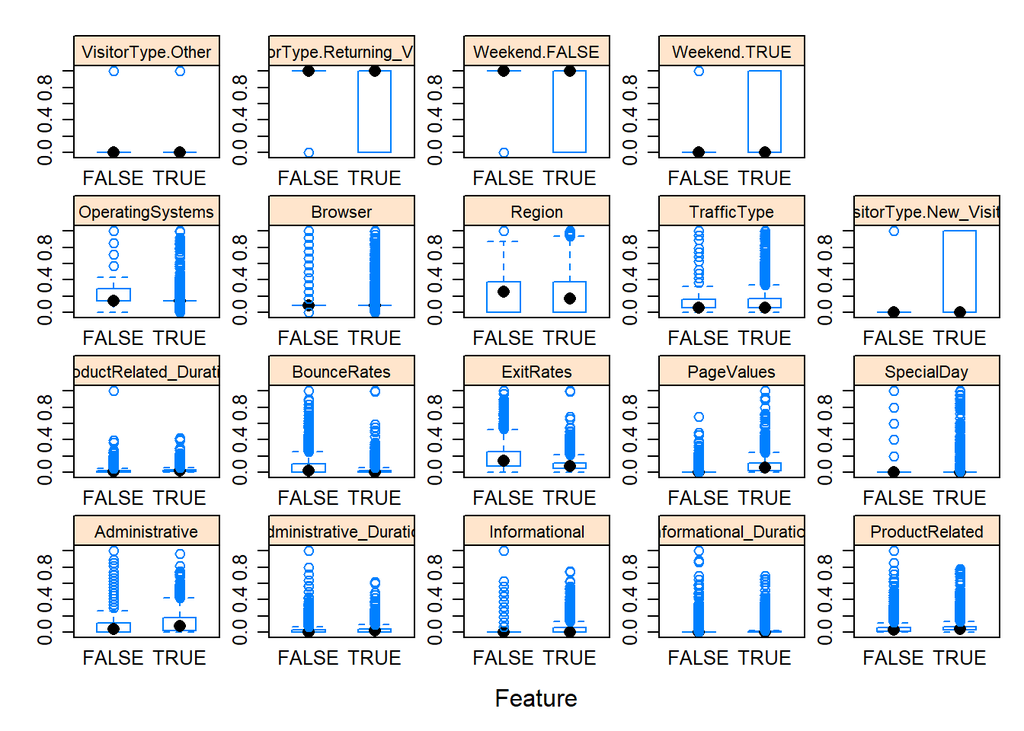

```r
# "box" or "density"
plot_type <- "box"
label_col_num <- (which(colnames(trainData) == label_name))

featurePlot(x = trainData[, -label_col_num],
            y = as.factor(trainData[, label_col_num]),
            plot = plot_type,
            strip=strip.custom(par.strip.text=list(cex=.7)),
            scales = list(x = list(relation="free"),
                          y = list(relation="free")))
```

# Prediction

Now, we improved some models and it is time to predict test data. You can see the general prediction step here.

```r
# Step 1: Impute missing values

testData2 <- predict(preProcess_missingdata_model, testData)

# Step 2: Create one-hot encodings (dummy variables)
testData3 <- predict(dummies_model, testData2)
# Step 3: Transform the features to range between 0 and 1
testData4 <- predict(preProcess_range_model, testData3)
```

# Performance Evaluation

I wrote a function that takes model and positive class as input name and gives confusion matrix as output. It needs preprocessed testData4 for analysing results. Here, we can see many performans metrics with the help of confusionMatrix function.

```r
see_conf <- function(m, positive_class){
  fitted <- predict(m, testData4)
  sel_positive <- positive_class
  label_col_num <- (which(colnames(testData) == label_name))
  confusionMatrix(reference = testData[,label_col_num], data = fitted, mode='everything',
                  positive=sel_positive)
}
```

# Models are created here

I used 5 well known model by default but users can use different models in main function.

```r
model_run <- function(m){
    set.seed(100)
    label_col_num <- (which(colnames(trainData) == label_name))
    created_model = train(trainData[,-label_col_num], trainData[,label_col_num],
                      method=as.character(m))
    return(created_model)
}
train_methods <- list('knn', 'lda', 'rf', 'naive_bayes', 'rpart')
models <- list()
for(i in 1:length(train_methods)){
  c_model = model_run(train_methods[i])
  models[[length(models) + 1]] <- c_model
}
```

[output not shown]

# Print Confusion Matrix

```r
for(i in 1:length(models)){
  temp_conf <- see_conf(models[[i]], 'TRUE')
  print(paste(train_methods[i], ' CONFUSION MATRIX'))
  print(temp_conf)
}
```

```
## [1] "knn  CONFUSION MATRIX"
## Confusion Matrix and Statistics
##
##           Reference
## Prediction FALSE TRUE
##      FALSE   889  224
##      TRUE    255  920
##
##                Accuracy : 0.7906
##                  95% CI : (0.7734, 0.8072)
##     No Information Rate : 0.5
##     P-Value [Acc > NIR] : <2e-16
##
##                   Kappa : 0.5813
##
##  Mcnemar's Test P-Value : 0.1705
##
##             Sensitivity : 0.8042
##             Specificity : 0.7771
##          Pos Pred Value : 0.7830
##          Neg Pred Value : 0.7987
##               Precision : 0.7830
##                  Recall : 0.8042
##                      F1 : 0.7934
##              Prevalence : 0.5000
##          Detection Rate : 0.4021
##    Detection Prevalence : 0.5135
##       Balanced Accuracy : 0.7906
##
##        'Positive' Class : TRUE
##
## [1] "lda  CONFUSION MATRIX"
## Confusion Matrix and Statistics
##
##           Reference
## Prediction FALSE TRUE
##      FALSE   960  286
##      TRUE    184  858
##
##                Accuracy : 0.7946
```

[output cut: 100 more lines]

```
##
##             Sensitivity : 0.8846
##             Specificity : 0.8820
##          Pos Pred Value : 0.8823
##          Neg Pred Value : 0.8843
##               Precision : 0.8823
##                  Recall : 0.8846
##                      F1 : 0.8835
##              Prevalence : 0.5000
##          Detection Rate : 0.4423
##    Detection Prevalence : 0.5013
##       Balanced Accuracy : 0.8833
##
##        'Positive' Class : TRUE
##
```

# Compare different models

For our online shopping intention dataset, random forest and decision tree models came forward. And the champion model is Random forest for the dataset with low standard deviation and high accuracy score. As you can see lowest accuracy score is above 90s accuracy score and also it has pretty high kappa value.

```r
compare_list <- list()
for(i in 1:length(train_methods)){
  compare_list[[train_methods[[i]]]] <- models[[i]]
}
# Compare model performances using resample()
models_compare <- resamples(compare_list)

# Summary of the models performances
summary(models_compare)
```

```
##
## Call:
## summary.resamples(object = models_compare)
##
## Models: knn, lda, rf, naive_bayes, rpart
## Number of resamples: 25
##
## Accuracy
##                  Min.   1st Qu.    Median      Mean   3rd Qu.      Max. NA's
## knn         0.7419355 0.7459475 0.7539659 0.7520426 0.7567568 0.7623145    0
## lda         0.7799043 0.7893962 0.7927187 0.7924219 0.7971488 0.8038450    0
## rf          0.9049043 0.9078097 0.9125874 0.9115611 0.9140995 0.9196992    0
## naive_bayes 0.6902497 0.8002963 0.8026510 0.7931576 0.8069555 0.8172107    0
## rpart       0.8848306 0.8897731 0.8923900 0.8921990 0.8953874 0.8987082    0
##
## Kappa
##                  Min.   1st Qu.    Median      Mean   3rd Qu.      Max. NA's
## knn         0.4839015 0.4919305 0.5078545 0.5041118 0.5134962 0.5247432    0
## lda         0.5591355 0.5785483 0.5854809 0.5848242 0.5944357 0.6077239    0
## rf          0.8097667 0.8156195 0.8251656 0.8231082 0.8280965 0.8393521    0
## naive_bayes 0.3854669 0.6004937 0.6059894 0.5866659 0.6140522 0.6346379    0
## rpart       0.7696678 0.7795708 0.7847574 0.7843790 0.7907161 0.7973898    0
```

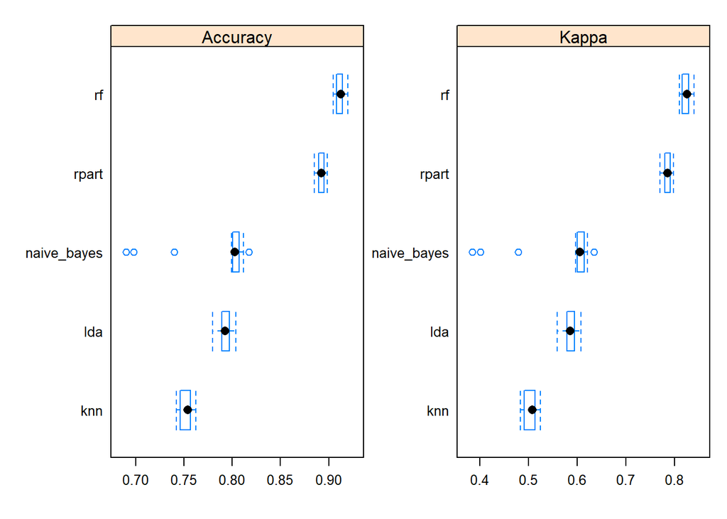

```r
# Draw box plots to compare models
scales <- list(x=list(relation="free"), y=list(relation="free"))
bwplot(models_compare, scales=scales)
```

# Visualize metrics

I visualized k and accuracy value graph, feature importance chart as well.

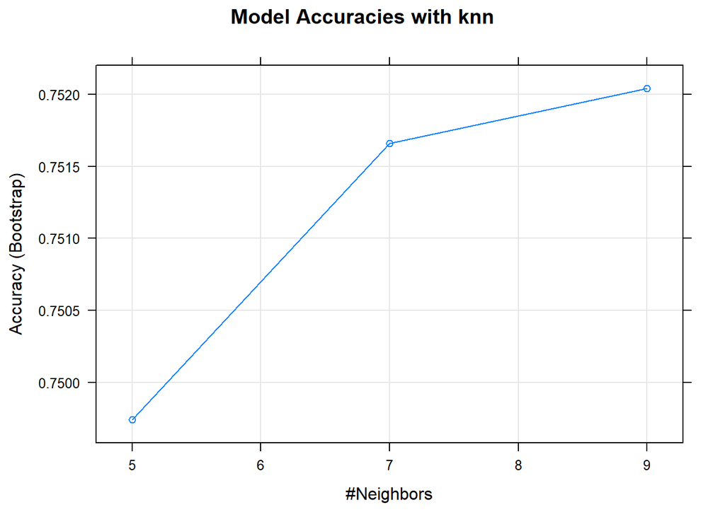

```r
plot(models[[1]], main=paste("Model Accuracies with", train_methods[[1]]))
```

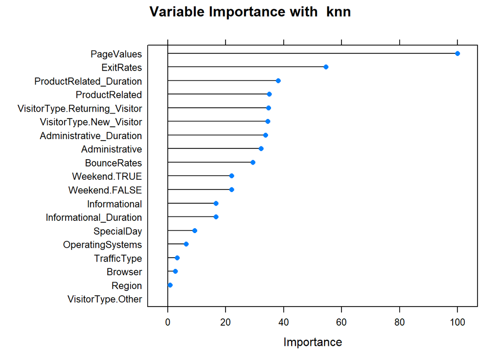

```r
varimp_knn <- varImp(models[[1]])
plot(varimp_knn, main=paste("Variable Importance with ", train_methods[[1]]))
```